# Machine Learning Assignment - Benoît GILBERT

This is my work for the machine learning class.

In the provided dataset, six young health participants were asked to perform one set of 10 repetitions of the Unilateral Dumbbell Biceps Curl in five different fashions: exactly according to the specification (Class A), throwing the elbows to the front (Class B), lifting the dumbbell only halfway (Class C), lowering the dumbbell only halfway (Class D) and throwing the hips to the front (Class E).

Sensors recorded various parameters during these exercises. Our goal is to predict the “classe” variable, based on what the sensors have measured.

# Loading data

```r
library(data.table); library(caret) # loading packages
setwd(dirname(rstudioapi::getActiveDocumentContext()$path)) # setting working directory
DATA <- setDT(read.csv(file = "pml-training.csv")[-1])
```

# Tidying data

This set contain several columns that are useless, because not directly obtained from sensors or not actual raw data. Let’s remove them :

```r
DATA <- DATA[ , c(grep("time", names(DATA), value = T)) := NULL ] # removing the timestanps
DATA <- DATA[, c(grep("user_name|window", names(DATA), value = T)) := NULL] # removing subject name and acquisition numbers
DATA <- DATA[ , c(grep("max|min|swewness|stddev|avg|var|skew|kurtosis|amplitude", names(DATA), value = T)) := NULL ] # removing the covariates (I only want to keep the raw measurement from the sensors)
DATA$classe <- as.factor(DATA$classe) # coercing as factor
```

Checking there are not other useless variables.

```r
nearZeroVar(DATA, names = TRUE)
```

```
## character(0)
```

Ok !

Let’s now use this DATA to create a training and testing set (because the provided TEST set, for the Quizz, is very small)

```r
set.seed(13)
training_index <- createDataPartition(y = DATA$classe, p = 0.7, list = FALSE)
training <- DATA[training_index,]
testing <- DATA[-training_index,]
```

# Training models

Given the high number of observations, the high number of variables, and the fact that my outcome contains several categories, I expect that an approach based on trees would solve the problem.

I will train using the two most common tools :  
* a random forest model,  
* and a Stochastic Gradient Boosting (GBM) (which also uses trees).

For each model, I will try with and without pre-possessing using Principal Coordinate Analysis (PCA).

```r
model1 <- train(classe ~. , method = "rf", data = training, trControl = trainControl(method = "cv", number = 2))
model1b <- train(classe ~. , preProcess = "pca", method = "rf", data = training, trControl = trainControl(method = "cv", number = 2))

model2 <- train(classe ~. ,  method = "gbm", data = training, trControl = trainControl(method = "repeatedcv", number = 2, repeats = 1), verbose = F)
model2b <- train(classe ~. , preProcess = "pca", method = "gbm", data = training, trControl = trainControl(method = "repeatedcv", number = 2, repeats = 1), verbose = F)
```

# Testing models

Let’s now evaluate accuracy of each model in the testing set

```r
# For model 1
test_m1 <- predict(model1, testing)
matrix_m1 <- confusionMatrix(test_m1, testing$classe)

# For model 1b
test_m1b <- predict(model1b, testing)
matrix_m1b <- confusionMatrix(test_m1b, testing$classe)

# For model 2
test_m2 <- predict(model2, testing)
matrix_m2 <- confusionMatrix(test_m2, testing$classe)

# For model 2b
test_m2b <- predict(model2b, testing)
matrix_m2b <- confusionMatrix(test_m2b, testing$classe)
```

Extracting accuracy of each model :

```r
data.frame(RF = matrix_m1$overall[[1]], RF_PCA = matrix_m1b$overall[[1]], GBM = matrix_m2$overall[[1]], GBM_PCA = matrix_m2b$overall[[1]])
```

```
##         RF    RF_PCA       GBM   GBM_PCA
## 1 0.991164 0.9736619 0.9638063 0.8117247
```

We see that pre-processing with PCA actually makes all models worse.

Model 1 (random forest) looks marginally better (99% accuracy). However Model2 (GBM) looks also fine (96% accuracy).

So here are the two models that I retain. We can print their summary:

```
## Random Forest
##
## 13737 samples
##    52 predictor
##     5 classes: 'A', 'B', 'C', 'D', 'E'
##
## No pre-processing
## Resampling: Cross-Validated (2 fold)
## Summary of sample sizes: 6869, 6868
## Resampling results across tuning parameters:
##
##   mtry  Accuracy   Kappa
##    2    0.9839848  0.9797365
##   27    0.9853681  0.9814903
##   52    0.9808549  0.9757827
##
## Accuracy was used to select the optimal model using the largest value.
## The final value used for the model was mtry = 27.
```

```
## Stochastic Gradient Boosting
##
## 13737 samples
##    52 predictor
##     5 classes: 'A', 'B', 'C', 'D', 'E'
##
## No pre-processing
## Resampling: Cross-Validated (2 fold, repeated 1 times)
## Summary of sample sizes: 6868, 6869
## Resampling results across tuning parameters:
##
##   interaction.depth  n.trees  Accuracy   Kappa
##   1                   50      0.7558419  0.6903025
##   1                  100      0.8203397  0.7725774
##   1                  150      0.8563732  0.8182474
##   2                   50      0.8541167  0.8152176
##   2                  100      0.9036908  0.8781429
##   2                  150      0.9261847  0.9066256
##   3                   50      0.8951738  0.8672758
##   3                  100      0.9372498  0.9206007
##   3                  150      0.9558126  0.9440937
##
## Tuning parameter 'shrinkage' was held constant at a value of 0.1
##
## Tuning parameter 'n.minobsinnode' was held constant at a value of 10
## Accuracy was used to select the optimal model using the largest value.
## The final values used for the model were n.trees = 150, interaction.depth =
##  3, shrinkage = 0.1 and n.minobsinnode = 10.
```

We can even have a look on the two most influential variables in model2 :

```
##                 rel.inf
## roll_belt     17.453220
## pitch_forearm  8.985612
```

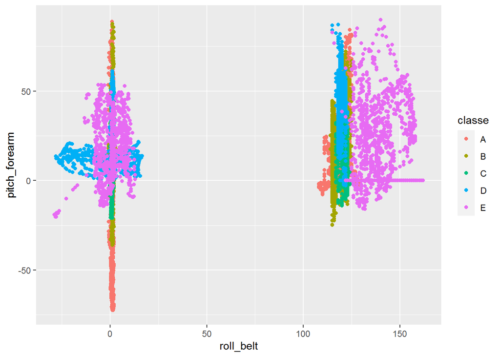

```r
qplot(roll_belt , pitch_forearm, data = training, col = classe)
```

# Final testing (Quizz test set)

I’ll finally test the two models on the provided little TEST set, for the Quizz

```r
TEST <- setDT(read.csv(file = "pml-testing.csv")[-1]) # loading TEST data
# For model 1
TEST_m1 <- predict(model1, TEST)
# For model 1
TEST_m2 <- predict(model2, TEST)
# Checking congruence
confusionMatrix(TEST_m1, TEST_m2)[2:3]
```

```
## $table
##           Reference
## Prediction A B C D E
##          A 7 0 0 0 0
##          B 0 8 0 0 0
##          C 0 0 1 0 0
##          D 0 0 0 1 0
##          E 0 0 0 0 3
##
## $overall
##       Accuracy          Kappa  AccuracyLower  AccuracyUpper   AccuracyNull
##   1.000000e+00   1.000000e+00   8.315665e-01   1.000000e+00   4.000000e-01
## AccuracyPValue  McnemarPValue
##   1.099512e-08            NaN
```

Both models agree on the prediction, with 100% accuracy ! Thus my answer to the Quizz will be :

```
##    Answer Question_id
## 1       B           1
## 2       A           2
## 3       B           3
## 4       A           4
## 5       A           5
## 6       E           6
## 7       D           7
## 8       B           8
## 9       A           9
## 10      A          10
## 11      B          11
## 12      C          12
## 13      B          13
## 14      A          14
## 15      E          15
## 16      E          16
## 17      A          17
## 18      B          18
## 19      B          19
## 20      B          20
```

# Out of Sample Error